# Chapter 2: Regression analysis

Roope Kaaronen

7 November 2018

## Data Analysis

This week I did some data wrangling on the JYTOPKYS2 dataset (and created my own learning2014.csv file) and subsequently ran some descriptive analyses as well as multiple and simple regression analyses on the data. The conclusion of these analyses was that, according to this dataset, study attitudes affect the statistics course scores (points) statistically significantly (p < 0.001).

*Step 1:*

I inspected the structure and dimensions of the learning2014 dataset I created in the data wrangling process.

The data had 166 observations and 7 variables. The variables are: gender (of student), age (of student), attitude (general attitude towards statistics), deep (deep learning strategies), stra (strategic learning strategies), surf (surface learning strategies) and points (score of statistics course).

*Step 2:*

Next I drew a scatterplot matrix to explore a graphical overview of the data:

```
## 'data.frame':    166 obs. of  7 variables:
##  $ gender  : Factor w/ 2 levels "F","M": 1 2 1 2 2 1 2 1 2 1 ...
##  $ age     : int  53 55 49 53 49 38 50 37 37 42 ...
##  $ attitude: num  3.7 3.1 2.5 3.5 3.7 3.8 3.5 2.9 3.8 2.1 ...
##  $ deep    : num  3.58 2.92 3.5 3.5 3.67 ...
##  $ stra    : num  3.38 2.75 3.62 3.12 3.62 ...
##  $ surf    : num  2.58 3.17 2.25 2.25 2.83 ...
##  $ points  : int  25 12 24 10 22 21 21 31 24 26 ...
```

```
## [1] 166   7
```

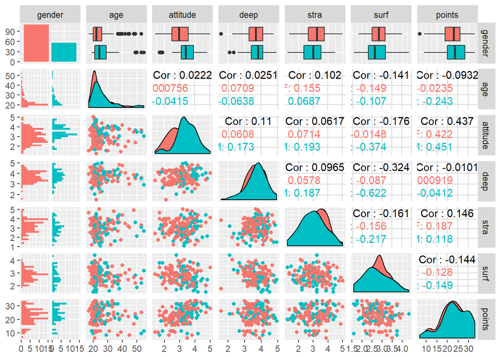

Here are some observations: Age: Age is (as expected) heavily positively skewed (since the participants are students). Mean age is 25.5. Age does not correlate strongly with any of the other variables.  
Attitude: Attitude seems to be quite normally distributed, with slight negative skew. Attitude correlates moderately with points (r = 0.437). This is an interesting finding.  
Deep: Deep learning is quite neatly normally distributed. Deep learning has weak negative correlation (r = -0.324) with surface learning. This makes sense: when deep learning increases in a student, we can expect surface learning to decrease.  
Stra: Strategic learning has a nice normal distribution, but correlations with the other variables are at best very weak.  
Surf: Surface learning correlates very weakly with the other variables (nothing significant here) except for deep learning (See above).  
Points: (When greater than zero) points averaged (mean) at 22.7, with the lowest score being 7 and the highest 33. The points distribution is negatively skewed. The distribution peaks around it’s mean, but also has a smaller peak around very high scores (around 30 points). Points have a moderate correlation with the attitude varialbe (r = 0.437).

Then I did a multiple regression model.

```
##
## Call:
## lm(formula = points ~ attitude + stra + surf, data = learning2014)
##
## Coefficients:
## (Intercept)     attitude         stra         surf
##     11.0171       3.3952       0.8531      -0.5861
```

```
##
## Call:
## lm(formula = points ~ attitude + stra + surf, data = learning2014)
##
## Residuals:
##      Min       1Q   Median       3Q      Max
## -17.1550  -3.4346   0.5156   3.6401  10.8952
##
## Coefficients:
##             Estimate Std. Error t value Pr(>|t|)
## (Intercept)  11.0171     3.6837   2.991  0.00322 **
## attitude      3.3952     0.5741   5.913 1.93e-08 ***
## stra          0.8531     0.5416   1.575  0.11716
## surf         -0.5861     0.8014  -0.731  0.46563
## ---
## Signif. codes:  0 '***' 0.001 '**' 0.01 '*' 0.05 '.' 0.1 ' ' 1
##
## Residual standard error: 5.296 on 162 degrees of freedom
## Multiple R-squared:  0.2074, Adjusted R-squared:  0.1927
## F-statistic: 14.13 on 3 and 162 DF,  p-value: 3.156e-08
```

Here is a summary for this analysis:

Multiple R-squared is 0.21. This implies that our model explains 21 % of the variance in points.

Since stra and surf were not significant, I chose to delete them form my model. This left me with a (nice) simple regression model with points as the dependent variable and attitude as the independent/explanatory variable:

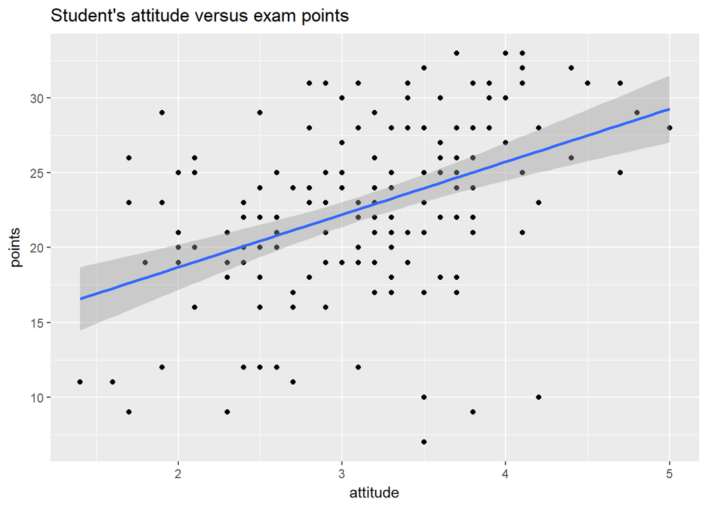

```
##
## Call:
## lm(formula = points ~ attitude, data = learning2014)
##
## Residuals:
##      Min       1Q   Median       3Q      Max
## -16.9763  -3.2119   0.4339   4.1534  10.6645
##
## Coefficients:
##             Estimate Std. Error t value Pr(>|t|)
## (Intercept)  11.6372     1.8303   6.358 1.95e-09 ***
## attitude      3.5255     0.5674   6.214 4.12e-09 ***
## ---
## Signif. codes:  0 '***' 0.001 '**' 0.01 '*' 0.05 '.' 0.1 ' ' 1
##
## Residual standard error: 5.32 on 164 degrees of freedom
## Multiple R-squared:  0.1906, Adjusted R-squared:  0.1856
## F-statistic: 38.61 on 1 and 164 DF,  p-value: 4.119e-09
```

Of course… What this does NOT imply is that attitudes cause high scores. There might be a third variable lurking behind attitudes towards statistics, such as general intelligence :-)

And then for some diagnostics:

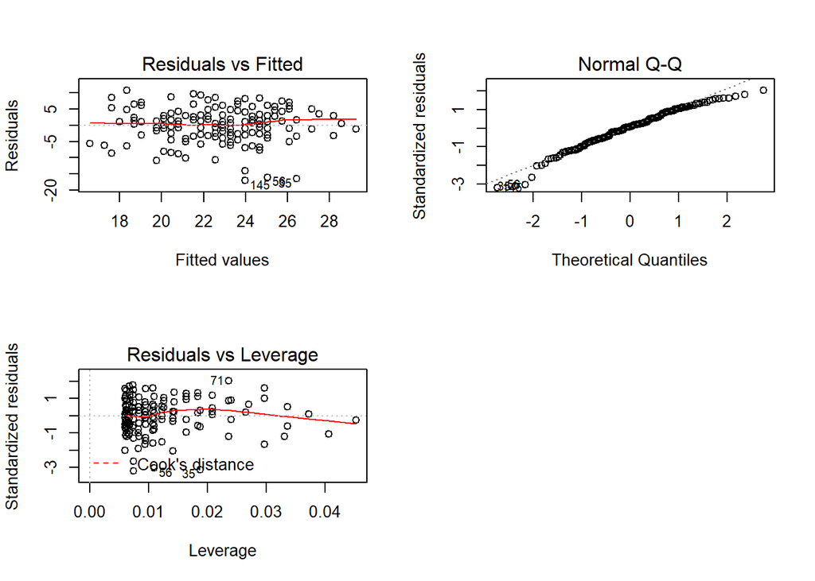

We use the QQ plot here to evaluate how well the distribution of errors in our dataset matches a standard normal distribution. The Q-Q plot above suggests that our dataset indeed is normally distributed. Only very slight symptoms of kurtosis and skew are shown. The Residuals vs Fitted plot is nicely evenly distributed with no significant patterns standing out, suggesting that the assumption of constant variance of errors is reasonable. Although we have some outlier cases (data points 145, 56 and 35), according to our Residuals vs Leverage plot these don’t have high leverage on our dataset, since the leverage values are relatively low. Conclusively, it’s safe to say that our model fulfils the assumptions required for a linear regression analysis (i.e. our findings are reliable).